# CITS4009 Project 1

Himakar GADHAM (23783777)

## Introduction

The data set analyzed can be obtained from the kaggle platform.*Global YouTube Statistics 2023*. https://www.kaggle.com/datasets/nelgiriyewithana/global-youtube-statistics-2023

An collection of YouTube content creators, this dataset offers an ideal road to analyze and acquire valuable insights from the luminaries of the platform.

With comprehensive details on top creators’ subscriber counts, video views, upload frequency, country of origin, earnings, and more, this treasure trove of information is a must-explore for aspiring content creators, data enthusiasts, and anyone intrigued by the ever-evolving online content landscape.

With this extraordinary dataset, you can immerse yourself in the world of YouTube success and gain access to a wealth of information.

## Data Loading, Extracting & Overview

Loading libraries

```r
library(shiny)
library(ggplot2)
library(dplyr)
library(ggthemes)
library(forcats)
library(vtreat)
library(gridExtra)
library(tidyr)
library(numform)
library(timeDate)
library(reshape2)
```

Loading the main data set.

```r
library(readr)
youtube <- read_csv("Global YouTube Statistics.csv")
```

EDA (Exploratory Data Analysis) is an essential iterative process in data analysis. Analysts and data scientists use statistical and visualization techniques to explore, summarize, and uncover insights, patterns, and relationships within a dataset. It’s not a one-time task but a continuous and evolving process, allowing for a deeper understanding of data characteristics and structures as you delve further into the information. EDA is integral to data analysis, enabling data-driven decision-making and the identification of trends and key insights.

Data Understanding: View the first few rows of the dataset. Let’s check first 6 observations.

```r
head(youtube)
```

[output not shown]

Initial Exploration - EDA begins with a preliminary examination of the dataset. This includes visualizing basic statistics, distributions, and relationships among variables to gain an initial understanding of the data.

One common step is to use the str() function, which provides an overview of the dataset’s structure. It helps in obtaining a fundamental understanding of the dataset’s composition and variable types

```r
str(youtube)
```

To prepare for meaningful visualizations, we plan to factorize certain variables, such as ‘category’ and ‘Country.’ Additionally, addressing missing values and filtering out extreme values will be essential for obtaining meaningful insights from the data.

To gain an initial overview of the dataset, we will utilize the ‘summary’ function. This function provides key summary statistics for integer and numeric variables, including measures such as the minimum, 1st quartile, median, mean, 3rd quartile, and maximum.

```r
summary(youtube)
```

Additionally, we noticed that when we used the ‘summary’ function for character variables, there were no descriptions provided. To enhance the interpretability and consistency of our data, we will apply factorization to these categorical variables. This transformation will prove valuable when creating meaningful visualizations and drawing insights from the dataset.

During the exploratory data analysis (EDA) process, we began generating hypotheses. One noteworthy hypothesis is that content in the ‘Entertainment’ and ‘Music’ categories tends to generate higher revenue compared to other fields. This suggests that aspiring YouTubers aiming for substantial income may find it advantageous to consider these categories as a potential starting point. These hypotheses serve as valuable starting points for our analysis, guiding us towards deeper investigations and insights.

## Initial Transformations

Data Type Conversion

```r
# Convert 'below columns' to a factor (categorical) variable
youtube <- within(youtube, {
          category      <- as.factor(category)
          Country       <- as.factor(Country)
          channel_type  <- as.factor(channel_type)
          created_month <- as.factor(created_month)
})
```

Modifying the Column names & then cleaning the data

```r
#There is a column name 'video views' whis is difficult yo use in ploting and also "Gross tertiary education enrollment (%)" that is big, we need to modify the column names.
colnames(youtube)[which(colnames(youtube) == 'video views')] <- 'video_views'
colnames(youtube)[which(colnames(youtube) == 'Gross tertiary education enrollment (%)')] <- 'Gross_Tertiary_Edu_Enrol'

#Gross_Tertiary_Edu_Enrol column states the %age population that has done education, this can never be more than 100%. So, changing all the values >100 to 100.
youtube <-
  mutate(youtube,
      Gross_Tertiary_Edu_Enrol = ifelse(Gross_Tertiary_Edu_Enrol >100, 100, Gross_Tertiary_Edu_Enrol))
```

As part of data preprocessing, we performed a data type conversion operation. Specifically, we created a new column by concatenating three existing columns: ‘Year,’ ‘Month,’ and ‘Date.’ This new column, which we named ‘new_date,’ allows us to represent dates in a standardized format. This transformation simplifies date-related operations and enhances the overall usability of the dataset.

```r
youtube <- youtube %>%
  mutate(
    # Create a new column "new_date" by combining year, month, and date
    new_date_str = paste(created_year, created_month, created_date, sep = "-")
  )
# Convert the concatenated string to a Date object
youtube$new_date <- as.Date(youtube$new_date_str, format = "%Y-%b-%d")
youtube <- youtube |>
  relocate(new_date, .after = Longitude)
# Optional: Since we don't need the intermediate concatenated string I Removed it.
youtube <- youtube[, -ncol(youtube)]
```

In order to improve the visual structure and understanding of our dataset, we rearranged the columns. Our goal was to arrange related variables in a more intuitive and organized manner.

```r
# Rearrange the columns for better visual understanding in tabular form

# First, rearrange the columns related to video views
youtube <- youtube |>
  relocate(video_views, .before = video_views_for_the_last_30_days)

# Next, relocate the 'channel_type' column to be near the 'category' column
youtube <- youtube |>
  relocate(channel_type, .before = category)

# Move the 'channel_type_rank' column to follow the 'channel_type' column
youtube <- youtube |>
  relocate(channel_type_rank, .after = channel_type)

# Move the 'country_rank' column to follow the 'Abbreviation' column
youtube <- youtube |>
  relocate(country_rank, .after = Abbreviation)

# Add a new 'Rural_Population' column by subtracting 'Urban_population' from 'Population'
youtube <- youtube |>
  mutate(Rural_population = Population - Urban_population)

# Rearrange the columns for 'Population,' 'Urban_population,' and 'Rural_population'
youtube <- youtube |>
  relocate(Population, .before = Urban_population)

youtube <- youtube |>
  relocate(Rural_population, .after = Urban_population)
```

Data Cleaning involves identifying and handling missing values, outliers, and inconsistencies in the data to ensure data quality and reliability. Let’s continue with description of the data cleaning process and analysis of missing values:

```r
# Data Cleaning and Analysis of Missing Values

# Identify and count missing values in each column
apply(is.na(youtube), 2, sum)
```

```
##                             rank                         Youtuber
##                                0                                0
##                      subscribers                     channel_type
##                                0                                0
##                channel_type_rank                         category
##                               33                                0
##                            Title                          uploads
##                                0                                0
##                          Country                     Abbreviation
##                                0                                0
##                     country_rank                 video_views_rank
##                              116                                1
##                      video_views video_views_for_the_last_30_days
##                                0                               56
##          lowest_monthly_earnings         highest_monthly_earnings
##                                0                                0
##           lowest_yearly_earnings          highest_yearly_earnings
##                                0                                0
##     subscribers_for_last_30_days                     created_year
##                              337                                5
##                    created_month                     created_date
##                                0                                5
##         Gross_Tertiary_Edu_Enrol                Unemployment rate
##                              123                              123
##                       Population                 Urban_population
##                              123                              123
##                 Rural_population                         Latitude
##                              123                              123
##                        Longitude                         new_date
##                              123                                5
```

The code above calculates the count of missing values (NAs) in each column of the ‘youtube’ dataset. This step is essential to understand the extent of missing data in the dataset and decide how to handle it appropriately.

The dataset reveals that the majority of columns do not contain any missing values. Among those that do, “subscribers_for_last_30_days” stands out with 337 missing values, followed by variables like Population, Latitude, and Longitude, which also exhibit missing data.

It is worth noting that the presence of ‘nan’ values in character columns like ‘Country’ and ‘category’ went unnoticed during our initial analysis. Additionally, the variable “video_views_for_last_30_days” is of particular significance to our analysis, but it contains 56 missing values. Given its importance and the potential impact on various related variables, addressing these missing values becomes crucial as we proceed with our analysis.

Lets have a closer look at numarical NA variables

```r
# Count missing values in each column
missing_counts <- colSums(is.na(youtube))

# Identify columns with missing values
columns_with_missing <- names(missing_counts[missing_counts > 0])

# Print the missing value counts for columns with NAs
print(missing_counts[columns_with_missing])
```

```
##                channel_type_rank                     country_rank
##                               33                              116
##                 video_views_rank video_views_for_the_last_30_days
##                                1                               56
##     subscribers_for_last_30_days                     created_year
##                              337                                5
##                     created_date         Gross_Tertiary_Edu_Enrol
##                                5                              123
##                Unemployment rate                       Population
##                              123                              123
##                 Urban_population                 Rural_population
##                              123                              123
##                         Latitude                        Longitude
##                              123                              123
##                         new_date
##                                5
```

To ensure the integrity of our analysis, we have chosen to focus on observations where the ‘video_views’ variable registers a value greater than 0. This filtering step allows us to exclude data entries where no video views are recorded, ensuring that our analysis is based on meaningful data points.

```r
# Filter observations with video views equal to 0
youtube <- youtube[youtube$video_views > 0,]

# Check for missing values in the filtered dataset
sum(is.na(youtube))
```

```
## [1] 1356
```

```r
# Remove rows with missing values in the 'rank' column
youtube <- youtube %>%
  filter(!is.na(rank))

# Check for missing values in the updated dataset
sum(is.na(youtube))
```

```
## [1] 1356
```

```r
# Replace NA with "unknown" for selected columns
selected_columns <- c("category", "Country", "Abbreviation", "channel_type")
# Replace with the actual column names you want to modify
youtube[selected_columns][is.na(youtube[selected_columns])] <- "unknown"

apply(is.na(youtube), 2, sum)
```

```
##                             rank                         Youtuber
##                                0                                0
##                      subscribers                     channel_type
##                                0                                0
##                channel_type_rank                         category
##                               30                                0
##                            Title                          uploads
##                                0                                0
##                          Country                     Abbreviation
##                                0                                0
##                     country_rank                 video_views_rank
##                              110                                1
##                      video_views video_views_for_the_last_30_days
##                                0                               51
##          lowest_monthly_earnings         highest_monthly_earnings
##                                0                                0
##           lowest_yearly_earnings          highest_yearly_earnings
##                                0                                0
##     subscribers_for_last_30_days                     created_year
##                              330                                5
##                    created_month                     created_date
##                                0                                5
##         Gross_Tertiary_Edu_Enrol                Unemployment rate
##                              117                              117
##                       Population                 Urban_population
##                              117                              117
##                 Rural_population                         Latitude
##                              117                              117
##                        Longitude                         new_date
##                              117                                5
```

Now lets apply factors to categorical variables so that we get the desired visualizations.

```r
# Define a vector of columns to be factored
col_to_be_factored <- c("category", "Country", "channel_type", "created_month")

# Apply factors to the specified columns
youtube[, col_to_be_factored] <- lapply(youtube[, col_to_be_factored], factor)
```

Next, my aim is to filter observations with missing values in the most crucial column. For this purpose, I created a new dataset, ‘clean_data_youtube,’ which will facilitate our comparisons and future editing tasks. Now, lets try to filter this observation with all NA values in most important column.

```r
clean_data_youtube <- youtube %>%
  filter(!is.na(video_views_for_the_last_30_days))
```

Let us analyse which categories gives you the highest earning (yearly)

```r
# Replace missing values in 'highest_yearly_earnings' with 0
youtube$highest_yearly_earnings <- ifelse(is.na(youtube$highest_yearly_earnings), 0, youtube$highest_yearly_earnings)

# Calculate the average earnings by category
category_avg_earnings <- youtube %>%
  group_by(category) %>%
  summarize(avg_earnings = mean(highest_yearly_earnings))

# View the results
category_avg_earnings
```

```
## # A tibble: 19 × 2
##    category              avg_earnings
##    <fct>                        <dbl>
##  1 Autos & Vehicles         13150000
##  2 Comedy                    8038623.
##  3 Education                 8324391.
##  4 Entertainment             7483962.
##  5 Film & Animation          8993082.
##  6 Gaming                    3252386.
##  7 Howto & Style             2316468.
##  8 Movies                    5450000
##  9 Music                     6643245.
## 10 nan                      13933298.
## 11 News & Politics           7707753.
## 12 Nonprofits & Activism     4700000
## 13 People & Blogs            6558866.
## 14 Pets & Animals            9575086.
## 15 Science & Technology      2415472.
## 16 Shows                    24384615.
## 17 Sports                    9615118.
## 18 Trailers                  4350000
## 19 Travel & Events           1500000
```

In this code, we calculate the average number of subscribers and the count of YouTubers within each category. The results are then arranged in descending order of average subscribers, helping us identify categories that tend to attract more subscribers

```r
# Calculate the average subscribers and count of YouTubers by category
youtube_best_category <- youtube %>%
  group_by(category) %>%
  summarize(
    Avg_subscribers = mean(subscribers, na.rm = TRUE),
    Number_of_YouTubers = n()
  ) %>%
  arrange(desc(Avg_subscribers))

# View the results
youtube_best_category
```

```
## # A tibble: 19 × 3
##    category              Avg_subscribers Number_of_YouTubers
##    <fct>                           <dbl>               <int>
##  1 Shows                       41615385.                  13
##  2 Trailers                    39000000                    2
##  3 Nonprofits & Activism       27750000                    2
##  4 Sports                      27109091.                  11
##  5 Education                   26542222.                  45
##  6 Music                       25717822.                 202
##  7 Movies                      25650000                    2
##  8 Film & Animation            25442222.                  45
##  9 Entertainment               21403320.                 241
## 10 People & Blogs              21056061.                 132
## 11 Gaming                      20852128.                  94
## 12 News & Politics             20630769.                  26
## 13 Comedy                      20123188.                  69
## 14 Howto & Style               19390000                   40
## 15 Science & Technology        18617647.                  17
## 16 nan                         18300000                   39
## 17 Pets & Animals              18100000                    4
## 18 Autos & Vehicles            17850000                    2
## 19 Travel & Events             12500000                    1
```

This output shows that the categories like “shows” and “Trailers” have a higher chance of getting more subscribers.

In this code, we calculate the average number of subscribers and the count of YouTubers within each country. The results are then arranged in descending order of the number of YouTubers, helping us identify countries with a higher number of YouTubers and, by extension, potentially more subscribers.

```r
# Calculate the average subscribers and count of YouTubers by country
youtube_country_subs <- youtube %>%
  group_by(Country) %>%
  summarize(
    Avg_subscribers = mean(subscribers, na.rm = TRUE),
    Number_of_YouTubers = n()
  ) %>%
  arrange(desc(Number_of_YouTubers))

# View the results
youtube_country_subs
```

```
## # A tibble: 50 × 3
##    Country        Avg_subscribers Number_of_YouTubers
##    <fct>                    <dbl>               <int>
##  1 United States        22779743.                 311
##  2 India                25658333.                 168
##  3 nan                  22474138.                 116
##  4 Brazil               19706452.                  62
##  5 United Kingdom       21334884.                  43
##  6 Mexico               18996970.                  33
##  7 Indonesia            19075000                   28
##  8 Spain                17504545.                  22
##  9 Thailand             21472222.                  18
## 10 South Korea          28335294.                  17
## # ℹ 40 more rows
```

Visualization plays a pivotal role in data analysis, offering a powerful means to both extract insights and communicate findings effectively. Employing a range of visualization techniques and statistical tools, I delved into the data, often uncovering fresh inquiries and revelations that sparked subsequent analyses.

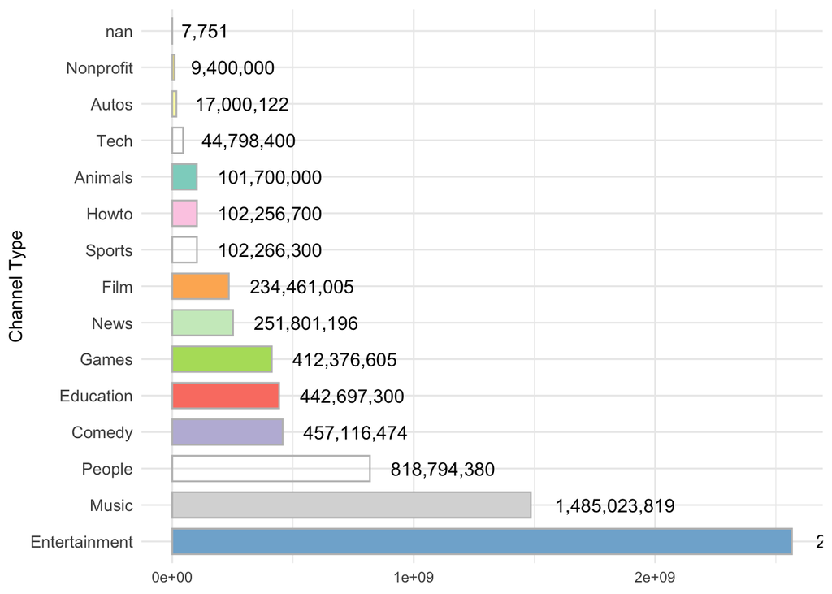

```r
# Summarize the data
summary_df <- youtube %>%
  group_by(channel_type) %>%
  summarise(sum_earnings = sum(highest_yearly_earnings)) %>%
  arrange(desc(sum_earnings))

# Create the bar plot
ggplot(summary_df, aes(x = reorder(channel_type, -sum_earnings), y = sum_earnings, fill = channel_type)) +
  geom_bar(stat = "identity", width = 0.7, color = "gray") +  # Adjust width and add white borders
  labs(
    x = "Channel Type",
    y = "Total Earnings",
    fill = "Channel Type"
  ) +
  theme_minimal() +
  coord_flip() +
  scale_fill_brewer(palette = "Set3") +  # Use a different color palette
  theme(
    axis.text.y = element_text(size = 10),  # Adjust text size on the y-axis
    axis.title.x = element_blank(),  # Remove x-axis label
    legend.position = "none"  # Remove legend
  ) +
  geom_text(aes(label = scales::comma(sum_earnings), hjust = -0.2), size = 4)  # Add labels to the bars
```

Histogram: Histograms to visualize the distribution of a numeric variable. This can help us understand the central tendency and spread of the data.

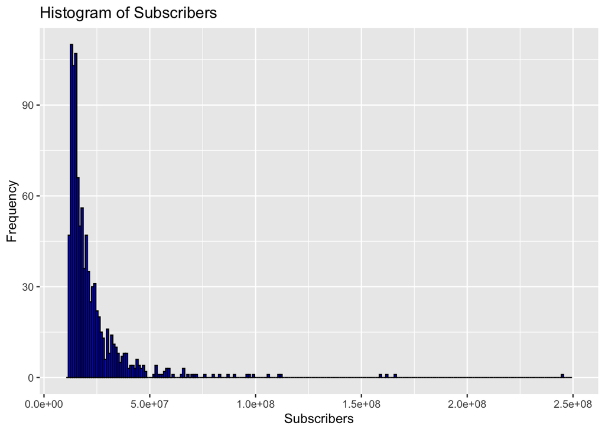

```r
# Remove rows with missing values in the subscribers column
clean_data_youtube1 <- youtube[!is.na(youtube$subscribers), ]

# Create the histogram
ggplot(data = clean_data_youtube1, aes(x = subscribers)) +
  geom_histogram(binwidth = 1000000, fill = "blue", color = "black") +
  labs(title = "Histogram of Subscribers",
       x = "Subscribers",
       y = "Frequency") +
  xlim(c(1e7, 2.5e8))
```

Scatter Plot: Scatter plots are great for visualizing the relationship between two numeric variables. We can use them to identify trends, correlations, or outliers.

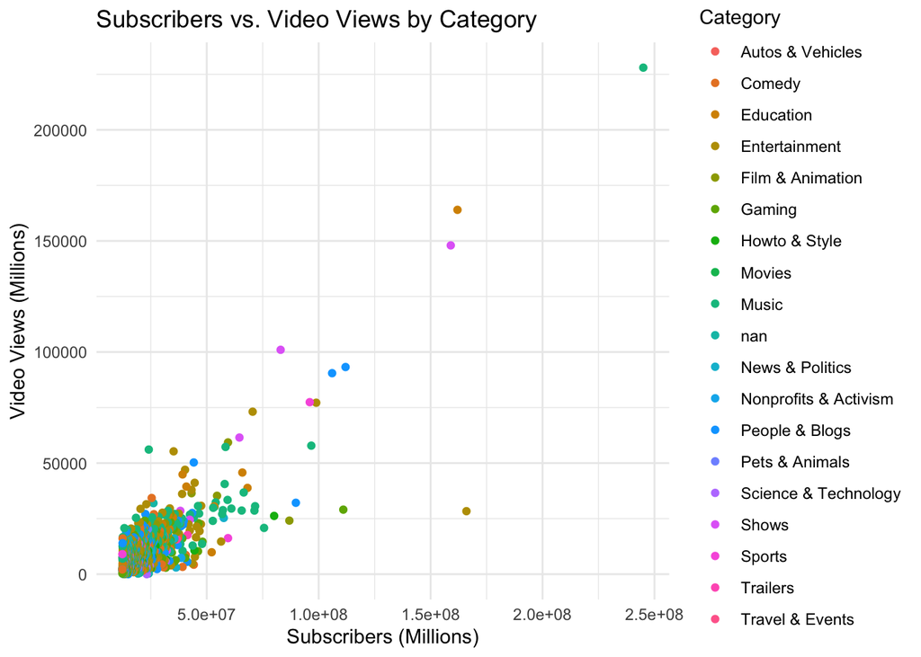

```r
cleaned_data_youtube <- youtube
# Data transformation: Convert 'created_month' to a factor for better visualization
cleaned_data_youtube$created_month <- factor(cleaned_data_youtube$created_month, levels = month.abb)

# Data transformation: Create a new variable 'earnings_range' based on earnings columns
cleaned_data_youtube$earnings_range <- ifelse(cleaned_data_youtube$highest_yearly_earnings >= 1e7, "High", "Low")

# Data transformation: Convert 'subscribers' and 'video_views' to millions for easier interpretation
cleaned_data_youtube$subscribers_millions <- cleaned_data_youtube$subscribers / 1e6
cleaned_data_youtube$video_views_millions <- cleaned_data_youtube$video_views / 1e6

# Scatter plot: Subscribers vs. Video Views
ggplot(cleaned_data_youtube, aes(x = subscribers, y = video_views_millions, color = category)) +
  geom_point() +
  labs(title = "Subscribers vs. Video Views by Category",
       x = "Subscribers (Millions)",
       y = "Video Views (Millions)",
       color = "Category") +
  theme_minimal()
```

The plot suggests that there is a positive relationship between the number of subscribers and the number of video views. As the number of subscribers increases, so does the number of video views.

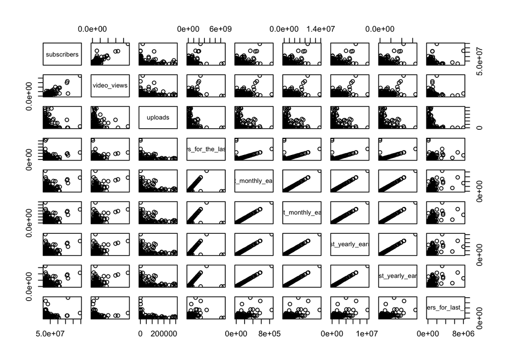

```r
# Scatter Plot Matrix for Numeric Variables
# Select numeric variables
numeric_vars <- cleaned_data_youtube %>%
  select(subscribers, video_views, uploads,
         video_views_for_the_last_30_days,
         lowest_monthly_earnings, highest_monthly_earnings,
         lowest_yearly_earnings, highest_yearly_earnings,
         subscribers_for_last_30_days)

# Create a scatterplot matrix
plot(numeric_vars)
```

Numarical varible matrix scatter plot

Bar Plot: A bar chart describes the comparisons between the discrete categories.

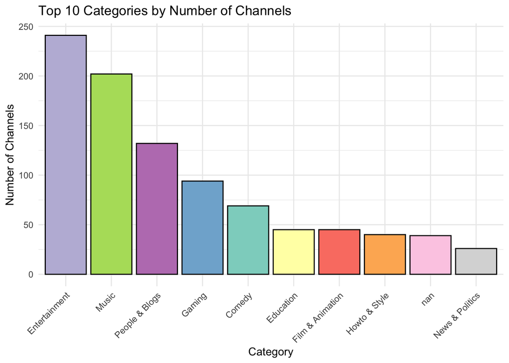

```r
# Bar plot: Top 10 categories by number of channels
top_categories <- cleaned_data_youtube %>%
  group_by(category) %>%
  summarise(count = n()) %>%
  arrange(desc(count)) %>%
  head(10)

# Create the bar plot
ggplot(top_categories, aes(x = reorder(category, -count), y = count, fill = category)) +
  geom_bar(stat = "identity", color = "black") +
  labs(
    title = "Top 10 Categories by Number of Channels",
    x = "Category",
    y = "Number of Channels"
  ) +
  theme_minimal() +
  theme(
    axis.text.x = element_text(angle = 45, hjust = 1),
    legend.position = "none"  # Remove legend
  ) +
  scale_fill_brewer(palette = "Set3")  # Use a different color palette
```

The graphical representation indicates that the number of channels in the Entertainment and Music categories is substantially higher compared to other categories in the dataset.

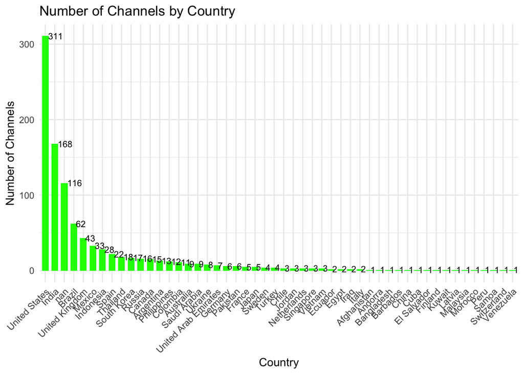

```r
# bar graph
country_counts <- cleaned_data_youtube %>%
  group_by(Country) %>%
  summarise(count = n())

ggplot(country_counts, aes(x = reorder(Country, -count), y = count, label = count)) +
  geom_bar(stat = "identity", fill = "green", width = 0.7) +
  geom_text(size = 3, hjust = -0.2) +  # Add data labels
  labs(title = "Number of Channels by Country", x = "Country", y = "Number of Channels") +
  theme_minimal() +
  theme(axis.text.x = element_text(angle = 45, hjust = 1))
```

The data clearly shows that the United States (US) has the highest number of YouTube channels, followed by other countries. This observation highlights the dominance of the US in terms of the number of channels represented in the dataset.

Heatmap: Heatmaps are useful for displaying relationships and patterns in a matrix of data.

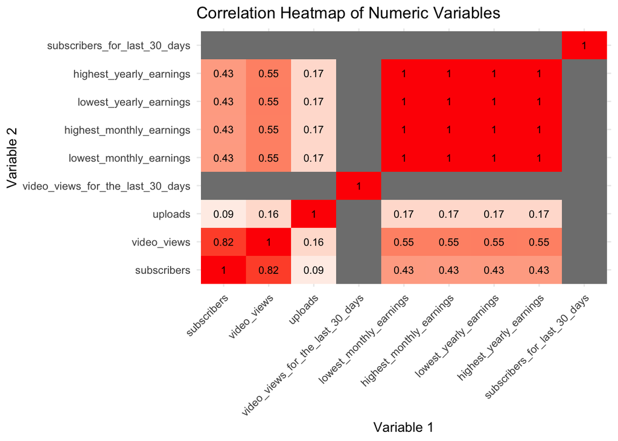

```r
# Calculate the correlation matrix
correlation_matrix <- cor(numeric_vars)

# Create a long-format data frame for the heatmap
correlation_data <- melt(correlation_matrix)

# Create the correlation heatmap
ggplot(data = correlation_data, aes(x = Var1, y = Var2, fill = value, label = round(value, 2))) +
  geom_tile() +
  geom_text(size = 3, color = "black") +  # Add correlation values
  labs(
    title = "Correlation Heatmap of Numeric Variables",
    x = "Variable 1",
    y = "Variable 2"
  ) +
  scale_fill_gradient2(low = "blue", mid = "white", high = "red", midpoint = 0) +  # Diverging color palette
  theme_minimal() +
  theme(
    axis.text.x = element_text(angle = 45, hjust = 1),
    legend.position = "none"  # Remove legend
  )
```

2D Histogram: A 2D histogram, also known as a density heatmap.

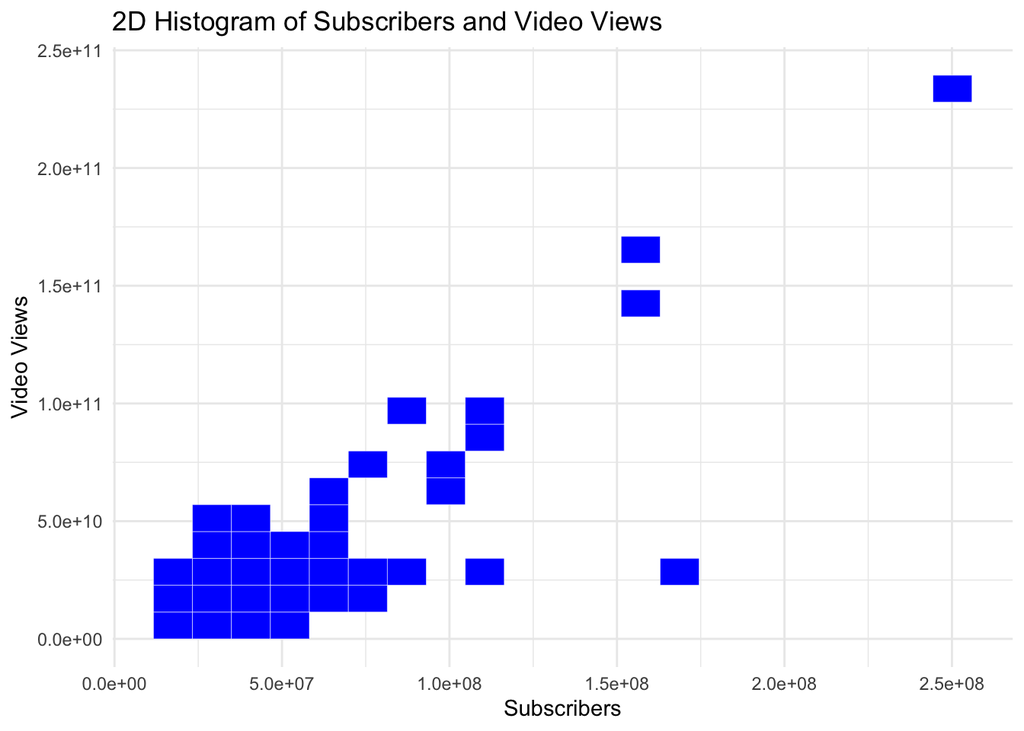

```r
# Create the 2D histogram
ggplot(cleaned_data_youtube, aes(x = subscribers, y = video_views)) +
  geom_bin2d(bins = 20, fill = "blue", color = "white") +  # Adjust the number of bins as needed
  labs(
    title = "2D Histogram of Subscribers and Video Views",
    x = "Subscribers",
    y = "Video Views"
  ) +
  scale_fill_gradient(low = "white", high = "blue") +
  theme_minimal()
```

Pie Chart: Pie charts are suitable for showing parts of a whole or the distribution of categorical data.

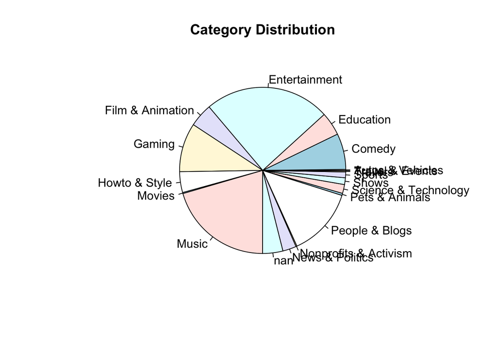

```r
pie(table(youtube$category), main = "Category Distribution")
```

Using a pie chart would be an effective way to visually represent the distribution of categories in the dataset. This chart type can provide a clear and concise overview of how different categories are distributed within the dataset.

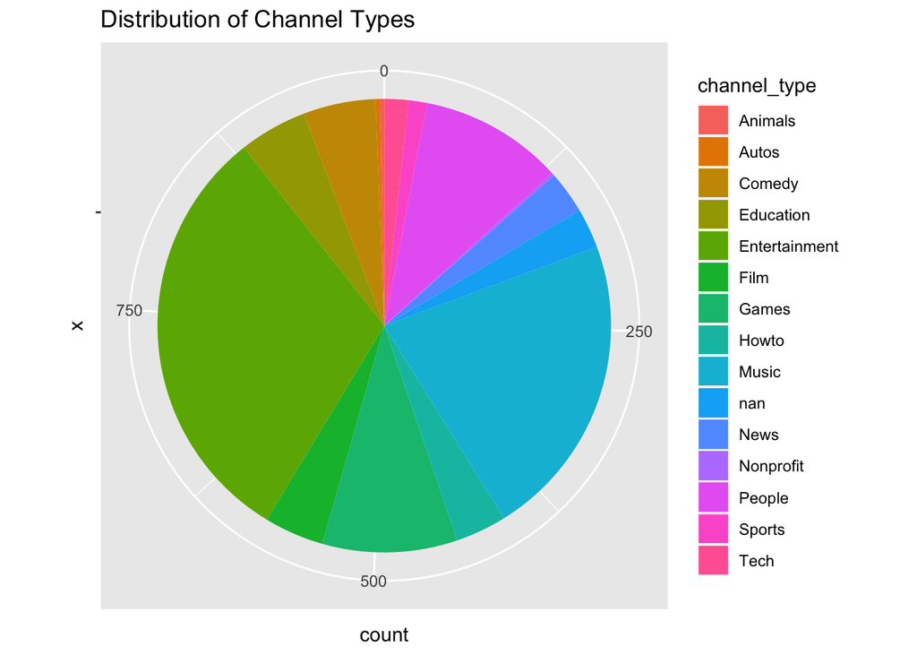

```r
# Create a summary of channel types
channel_type_summary <- cleaned_data_youtube %>%
  group_by(channel_type) %>%
  summarise(count = n())

# Create a pie chart
ggplot(channel_type_summary, aes(x = "", y = count, fill = channel_type)) +
  geom_bar(stat = "identity") +
  coord_polar("y") +
  labs(title = "Distribution of Channel Types")
```

I have represented the distribution of channel types in a pie chart. This chart visually illustrates the proportion of each channel type within the dataset, making it easy to see the relative distribution of channel types.

Box Plot: Box plots provide a summary of the distribution of a numeric variable, including median, quartiles, and potential outliers.

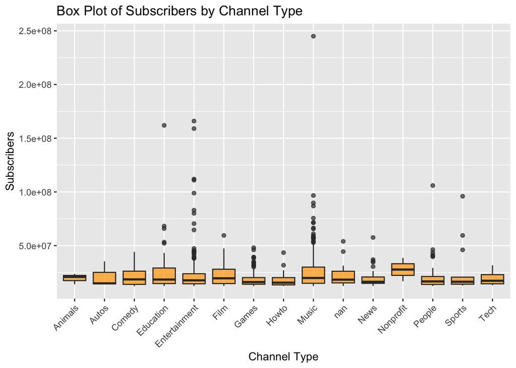

```r
# Create a box plot of subscribers by channel type
ggplot(cleaned_data_youtube, aes(x = channel_type, y = subscribers)) +
  geom_boxplot(fill = "orange", alpha = 0.7) +
  labs(
    title = "Box Plot of Subscribers by Channel Type",
    x = "Channel Type",
    y = "Subscribers"
  ) +
  theme(axis.text.x = element_text(angle = 45, hjust = 1))
```

The box plot provides a visual representation of the variation in the number of subscribers among different channel types. It allows us to observe the distribution of subscribers within each channel category, including measures such as the median, quartiles, and potential outliers. This helps us understand the subscriber distribution patterns across various channel types.

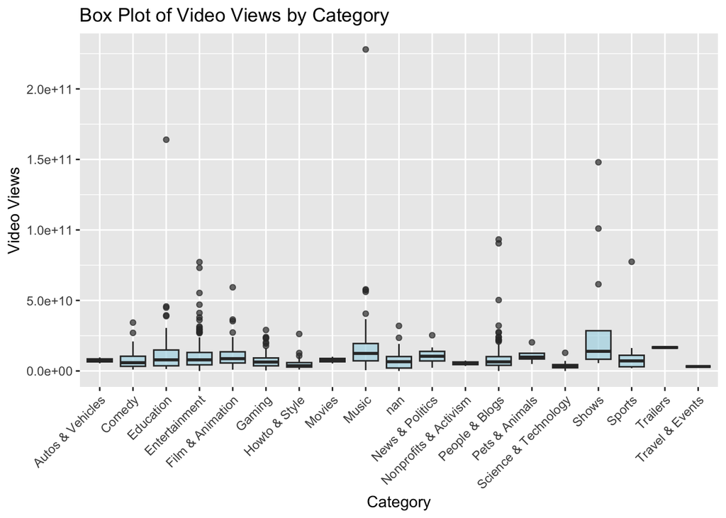

```r
# Create a box plot of video views by category
ggplot(cleaned_data_youtube, aes(x = category, y = video_views)) +
  geom_boxplot(fill = "lightblue", alpha = 0.7) +
  labs(
    title = "Box Plot of Video Views by Category",
    x = "Category",
    y = "Video Views"
  ) +
  theme(axis.text.x = element_text(angle = 45, hjust = 1))
```

The box plot offers insights into the variation of video views among different video categories. It provides a visual summary of the distribution of video views within each category, highlighting key statistics such as the median, quartiles, and potential outliers. This graphical representation aids in understanding how video views are distributed across various content categories.

## Validation and Verification

The EDA process frequently involves collaboration and feedback from team members or domain experts. Their valuable input can stimulate new questions and fresh perspectives, sparking additional iterations and refinements in our analysis.

## Future Avenues

The insights acquired through EDA often require effective communication with stakeholders. This interaction can stimulate fresh inquiries and input, setting the stage for another cycle of refinement and exploration.

## Conclusion

In conclusion, EDA stands as a pivotal pillar in the realm of modeling and feature engineering. Its significance lies in its ability to identify pertinent features and facilitate the creation of novel variables, thus enriching the landscape of predictive modeling. Throughout the modeling journey, revisiting EDA proves instrumental in offering valuable glimpses into the model’s performance and serves as a compass for refining our strategies.

Furthermore, the dynamic nature of data cannot be ignored. With the potential influx of new data or modifications to the existing dataset, a revisitation of the EDA process becomes not just beneficial but often necessary. This ensures that our insights remain pertinent and our models stay abreast of the latest developments.

The iterative voyage of EDA has proven invaluable, enabling the unearthing of profound insights and an ever-evolving grasp of the dataset. This iterative exploration serves as an indispensable bedrock that steers subsequent analyses, shapes the model-building journey, and contributes significantly to informed decision-making.

## References

1. ChatGPT - The code and syntax presented in this project draw inspiration from ChatGPT for code generation and syntax guidance.
2. YouTube - YouTube was referred to for clarification and guidance on utilizing specific code snippets related to data analysis and manipulation.
3. Academic Materials - The project benefited from previous year examples, lecture materials, and laboratory resources provided by the faculty to develop a comprehensive understanding of the subject matter and complete the project successfully.